# Lecture 9 - Tree-Based Methods

Joseph Haymaker

11/14/2017

# Tree based methods

- Text book
- 5.2: Bootstrap
- 8.1: Single trees
- 8.2: Ensemble methods
  - Bagging
  - Random Forest
  - Boosting

## Part I: regression trees

#### 1) Single Tree

#### 2) Bagging

#### 3) Random Forest (Bagging is a special case)

#### 4) Appendices (all about trees)

#### Appendix I: Testing errors vs. OOB testing erros

#### Appendix II: Effects for different Bootstrap samples on a single tree

#### Appendix III: Comparison among a single tree, bagging and rf

#### 5) Boosting

## Part II: RandomForest for classifications ( a separate file)

```r
library(tree)              # regression/classification trees
library(randomForest)      # to see how a package is evolved to be better: rfNews()
```

##### Part I: Regression trees

For the purpose of demonstration we use the Baseball data from the book. + Goal: predict log salary given the past performance!

```r
library(ISLR)
help(Hitters)
data.comp <- na.omit(Hitters)  # For simplicity
dim(data.comp)            # We are keeping 263 players
```

```
## [1] 263  20
```

```r
data.comp$LogSalary <- log(data.comp$Salary)  # add LogSalary
names(data.comp)
```

```
##  [1] "AtBat"     "Hits"      "HmRun"     "Runs"      "RBI"
##  [6] "Walks"     "Years"     "CAtBat"    "CHits"     "CHmRun"
## [11] "CRuns"     "CRBI"      "CWalks"    "League"    "Division"
## [16] "PutOuts"   "Assists"   "Errors"    "Salary"    "NewLeague"
## [21] "LogSalary"
```

```r
data1 <- data.comp[,-19]        # Take Salary out
```

#### 1) A single tree

The idea is to partition the space into boxes. + `Binary split`: Take the best predictor + `Recursive`: Repeat the search in the next half space + `The prediction`: sample mean in each box. + (one could use different method: reg for example)

**A single tree** + Pros: + not a linear model, more flexible + take interactions among variables + simple interpretation of the prediction + Cons: + not stable + overfitting or not a good prediction

We use it here to illustrate the idea of binary, top-down, recursive trees.

##### Model 0:

1. Use `CAtBat` alone to see the step function
- Good start to understand a tree.

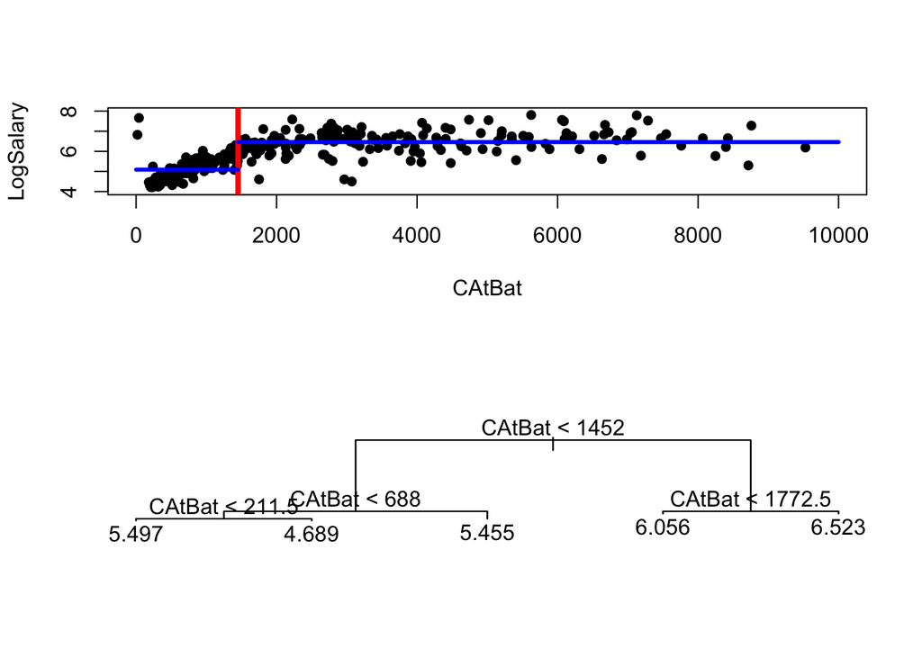

```r
par(mfrow=c(2,1))

# First optimal split: the node and the estimates
plot(NA, NA, type = "n", xlim = c(0,10000), ylim = c(4, 8), xlab = "CAtBat", ylab = "LogSalary")
points(data1$CAtBat, data1$LogSalary, pch=16)
abline(v=1452, col= "red", lwd=4)
lines(x = c(0,1452), y = c(5.09, 5.09), lwd=3, col="blue")
lines(x = c(1452, 10000), y = c(6.46, 6.46), lwd=3, col="blue")


fit0.single <- tree(LogSalary~CAtBat, data1)
plot(fit0.single)
text(fit0.single, pretty=0)   # add the split variables
```

```r
par(mfrow=c(1,1))

fit0.single$frame   # details in each split
```

```
##      var   n        dev     yval splits.cutleft splits.cutright
## 1 CAtBat 263 207.153733 5.927222          <1452           >1452
## 2 CAtBat 103  36.219531 5.092883           <688            >688
## 4 CAtBat  54  18.324402 4.764117         <211.5          >211.5
## 8 <leaf>   5  10.550154 5.496828
## 9 <leaf>  49   4.816009 4.689350
## 5 <leaf>  49   5.626109 5.455197
## 3 CAtBat 160  53.076591 6.464327        <1772.5         >1772.5
## 6 <leaf>  20   3.593939 6.055648
## 7 <leaf> 140  45.665082 6.522710
```

```r
summary(fit0.single)
```

```
##
## Regression tree:
## tree(formula = LogSalary ~ CAtBat, data = data1)
## Number of terminal nodes:  5
## Residual mean deviance:  0.2723 = 70.25 / 258
## Distribution of residuals:
##     Min.  1st Qu.   Median     Mean  3rd Qu.     Max.
## -2.02300 -0.26830  0.02837  0.00000  0.25970  2.16600
```

```
 var   n        dev     yval splits.cutleft splits.cutright
 1 CAtBat 263 207.153733 5.927222          <1452           >1452
 2 CAtBat 103  36.219531 5.092883           <688            >688
 4 CAtBat  54  18.324402 4.764117         <211.5          >211.5
 8 <leaf>   5  10.550154 5.496828
 9 <leaf>  49   4.816009 4.689350
 5 <leaf>  49   5.626109 5.455197
 3 CAtBat 160  53.076591 6.464327        <1772.5         >1772.5
 6 <leaf>  20   3.593939 6.055648
 7 <leaf> 140  45.665082 6.522710
```

2. Use `CHits` alone to see the step function

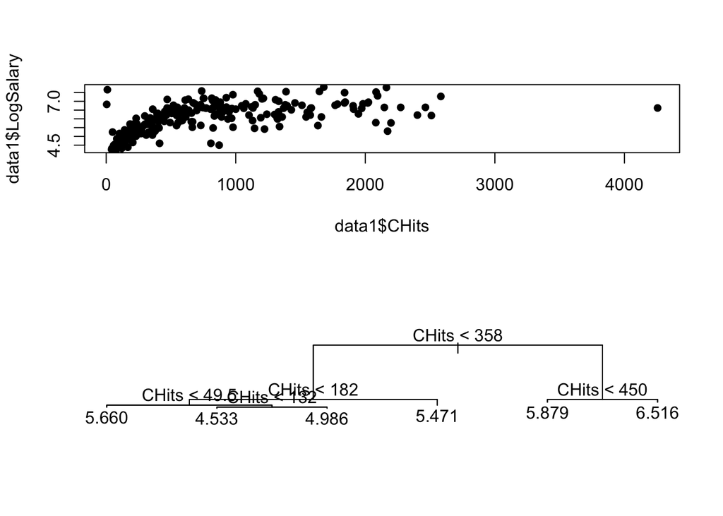

```r
par(mfrow=c(2,1))
plot(data1$CHits, data1$LogSalary, pch=16)
fit0.single <- tree(LogSalary~CHits, data1)
plot(fit0.single)
text(fit0.single, pretty=0)  # add the splits
```

```r
par(mfrow=c(1,1))
fit0.single$frame  # report the nodes
```

```
##       var   n         dev     yval splits.cutleft splits.cutright
## 1   CHits 263 207.1537331 5.927222           <358            >358
## 2   CHits 101  35.2429757 5.083074           <182            >182
## 4   CHits  56  18.3590026 4.771243          <49.5           >49.5
## 8  <leaf>   5   9.3315033 5.660001
## 9   CHits  51   4.6908471 4.684110           <132            >132
## 18 <leaf>  34   1.6206148 4.533326
## 19 <leaf>  17   0.7511846 4.985678
## 5  <leaf>  45   4.6621832 5.471130
## 3   CHits 162  55.0688493 6.453511           <450            >450
## 6  <leaf>  16   3.2773291 5.878956
## 7  <leaf> 146  45.9308869 6.516476
```

```
#       var   n         dev     yval splits.cutleft splits.cutright
# 1   CHits 263 207.1537331 5.927222           <358            >358
# 2   CHits 101  35.2429757 5.083074           <182            >182
# 4   CHits  56  18.3590026 4.771243          <49.5           >49.5
# 8  <leaf>   5   9.3315033 5.660001
# 9   CHits  51   4.6908471 4.684110           <132            >132
# 18 <leaf>  34   1.6206148 4.533326
# 19 <leaf>  17   0.7511846 4.985678
# 5  <leaf>  45   4.6621832 5.471130
# 3   CHits 162  55.0688493 6.453511           <450            >450
# 6  <leaf>  16   3.2773291 5.878956
# 7  <leaf> 146  45.9308869 6.516476
```

##### Model 1: Use all the obs’n but only include two variables CHits and CAtBat

```r
fit1.single <- tree(LogSalary~CAtBat+CHits, data1) # The order plays no role
fit1.single
```

```
## node), split, n, deviance, yval
##       * denotes terminal node
##
##  1) root 263 207.2000 5.927
##    2) CAtBat < 1452 103  36.2200 5.093
##      4) CHits < 182 56  18.3600 4.771
##        8) CHits < 49.5 5   9.3320 5.660 *
##        9) CHits > 49.5 51   4.6910 4.684
##         18) CHits < 132 34   1.6210 4.533 *
##         19) CHits > 132 17   0.7512 4.986 *
##      5) CHits > 182 47   5.1650 5.476 *
##    3) CAtBat > 1452 160  53.0800 6.464
##      6) CHits < 669 50   9.5000 6.214 *
##      7) CHits > 669 110  39.0100 6.578 *
```

```r
names(fit1.single)
```

```
## [1] "frame"   "where"   "terms"   "call"    "y"       "weights"
```

```r
fit1.single$frame
```

```
##       var   n         dev     yval splits.cutleft splits.cutright
## 1  CAtBat 263 207.1537331 5.927222          <1452           >1452
## 2   CHits 103  36.2195305 5.092883           <182            >182
## 4   CHits  56  18.3590026 4.771243          <49.5           >49.5
## 8  <leaf>   5   9.3315033 5.660001
## 9   CHits  51   4.6908471 4.684110           <132            >132
## 18 <leaf>  34   1.6206148 4.533326
## 19 <leaf>  17   0.7511846 4.985678
## 5  <leaf>  47   5.1645460 5.476113
## 3   CHits 160  53.0765908 6.464327           <669            >669
## 6  <leaf>  50   9.5004560 6.213632
## 7  <leaf> 110  39.0053795 6.578279
```

```
       var   n         dev     yval splits.cutleft splits.cutright
  1  CAtBat 263 207.1537331 5.927222          <1452           >1452
  2   CHits 103  36.2195305 5.092883           <182            >182
  4   CHits  56  18.3590026 4.771243          <49.5           >49.5
  8  <leaf>   5   9.3315033 5.660001
  9   CHits  51   4.6908471 4.684110           <132            >132
  18 <leaf>  34   1.6206148 4.533326
  19 <leaf>  17   0.7511846 4.985678
  5  <leaf>  47   5.1645460 5.476113
  3   CHits 160  53.0765908 6.464327           <669            >669
  6  <leaf>  50   9.5004560 6.213632
  7  <leaf> 110  39.0053795 6.578279
```

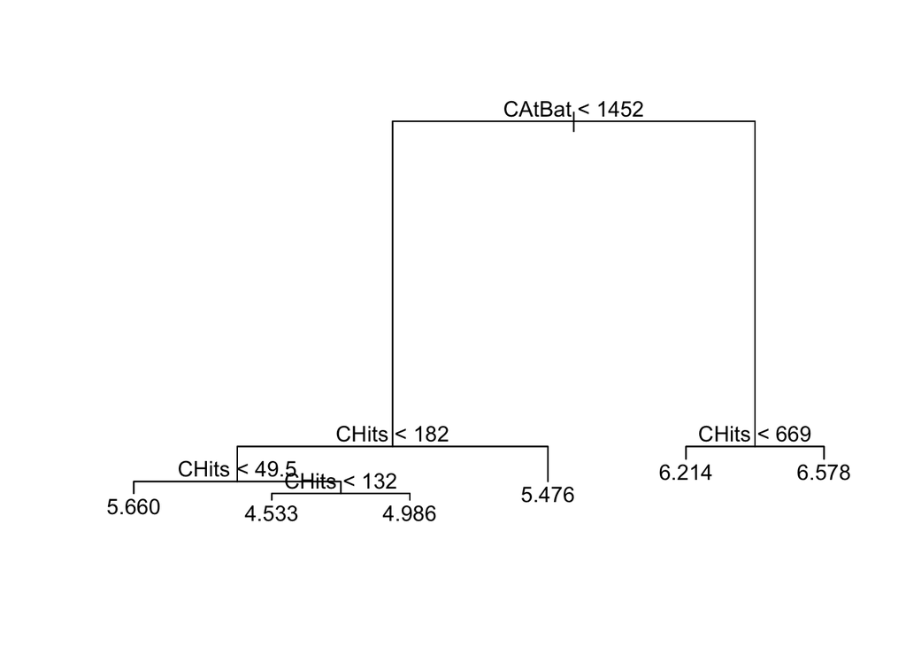

```r
plot(fit1.single)
text(fit1.single, pretty=0)
```

- `pretty`=0 only affect the categorical var’s. The names will be shown.
- It has 6 terminal nodes. That means we partition `CAtBat` and `Chits` into six boxes.
- The predicted values are the sample means in each box.

```r
fit1.single.result <- summary(fit1.single)
names(fit1.single.result)
```

```
## [1] "call"      "type"      "size"      "df"        "dev"       "residuals"
```

```r
fit1.single.result$dev # dev=RSS.
```

```
## [1] 65.37368
```

```r
fit1.single.result$size  # number of nodes
```

```
## [1] 6
```

```r
fit1.single.result$df  # n- number of nodes
```

```
## [1] 257
```

- RSS=65.37. It should be same as the sum of RSS at each `terminal node``
- 9.332+1.621+0.751+5.165+9.500+39.010=65.38 (should be the same)

```r
yhat <- predict(fit1.single, data1)  # only size=6 many predicted values
RSS.tree <- sum((data1$LogSalary-yhat)^2 )   # another way to get RSS
RSS.tree  #or
```

```
## [1] 65.37368
```

```r
sum((fit1.single.result$res)^2)
```

```
## [1] 65.37368
```

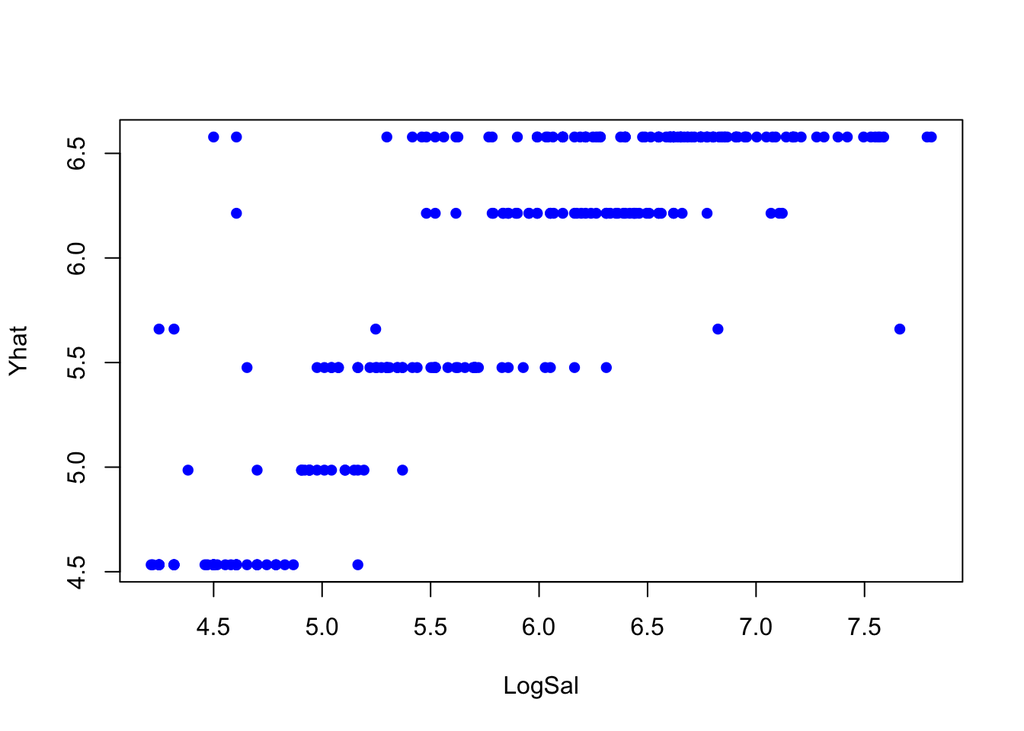

```r
# [1] 65.37368

plot(data1$LogSalary, yhat, pch=16, col="blue",
     xlab="LogSal",
     ylab="Yhat")
```

As we already knew there are only **6 predicted values** being used.

**QUESTION**: How does the above tree perform comparing with our old friend lm in terms of the in sample errors?

```r
fit.lm <- summary(lm(LogSalary~CAtBat+CHits, data1))
RSS.lm <- (263-2)*(fit.lm$sigma)^2
RSS.lm ## Oppps much worse than even a single tree.
```

```
## [1] 127.2509
```

```r
# [1] 127.2509   RSS.tree=65, in sample RSS is much smaller from the above tree.
```

##### An alternative tree (I like its output)

```r
library(rpart)
fit.single.rp <- rpart(LogSalary~CAtBat+CHits, data1, minsplit=20, cp=.009)
fit.single.rp
```

```
## n= 263
##
## node), split, n, deviance, yval
##       * denotes terminal node
##
##  1) root 263 207.1537000 5.927222
##    2) CAtBat< 1452 103  36.2195300 5.092883
##      4) CHits< 182 56  18.3590000 4.771243
##        8) CHits>=52.5 49   4.2615080 4.702633
##         16) CHits< 132 32   1.4248400 4.552265 *
##         17) CHits>=132 17   0.7511846 4.985678 *
##        9) CHits< 52.5 7  12.2521800 5.251518 *
##      5) CHits>=182 47   5.1645460 5.476113 *
##    3) CAtBat>=1452 160  53.0765900 6.464327
##      6) CHits< 669 50   9.5004560 6.213632 *
##      7) CHits>=669 110  39.0053800 6.578279 *
```

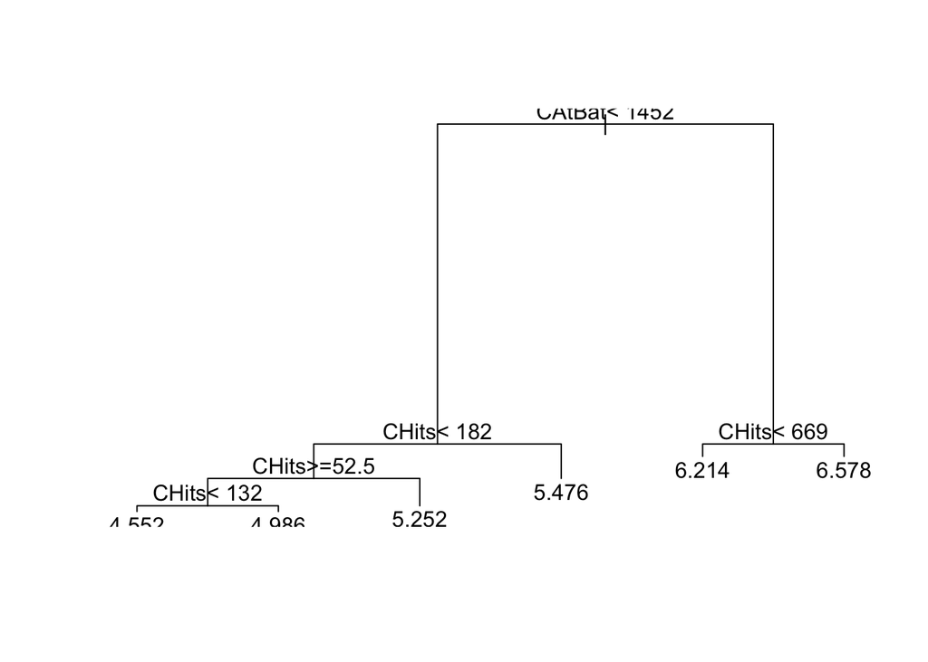

```r
plot(fit.single.rp)
text(fit.single.rp, pretty = TRUE)   # plot method 1
```

```r
summary(fit.single.rp)
```

```
## Call:
## rpart(formula = LogSalary ~ CAtBat + CHits, data = data1, minsplit = 20,
##     cp = 0.009)
##   n= 263
##
##            CP nsplit rel error    xerror       xstd
## 1 0.568937909      0 1.0000000 1.0031289 0.06514202
## 2 0.061287729      1 0.4310621 0.4596296 0.05189232
## 3 0.022064556      2 0.3697744 0.3988014 0.05859715
## 4 0.009487629      3 0.3477098 0.3803102 0.05890701
## 5 0.009000000      5 0.3287345 0.3998163 0.05955835
##
## Variable importance
## CAtBat  CHits
##     50     50
##
## Node number 1: 263 observations,    complexity param=0.5689379
##   mean=5.927222, MSE=0.7876568
##   left son=2 (103 obs) right son=3 (160 obs)
##   Primary splits:
##       CAtBat < 1452   to the left,  improve=0.5689379, (0 missing)
##       CHits  < 358    to the left,  improve=0.5640348, (0 missing)
##   Surrogate splits:
##       CHits < 358    to the left,  agree=0.985, adj=0.961, (0 split)
##
## Node number 2: 103 observations,    complexity param=0.06128773
##   mean=5.092883, MSE=0.3516459
##   left son=4 (56 obs) right son=5 (47 obs)
##   Primary splits:
##       CHits  < 182    to the left,  improve=0.3505286, (0 missing)
##       CAtBat < 688    to the left,  improve=0.3387404, (0 missing)
##   Surrogate splits:
##       CAtBat < 728.5  to the left,  agree=0.971, adj=0.936, (0 split)
##
## Node number 3: 160 observations,    complexity param=0.02206456
##   mean=6.464327, MSE=0.3317287
##   left son=6 (50 obs) right son=7 (110 obs)
##   Primary splits:
##       CHits  < 669    to the left,  improve=0.08611622, (0 missing)
##       CAtBat < 1772.5 to the left,  improve=0.07192567, (0 missing)
```

[output cut: 23 more lines]

```
##   left son=16 (32 obs) right son=17 (17 obs)
##   Primary splits:
##       CHits  < 132    to the left,  improve=0.4893769, (0 missing)
##       CAtBat < 532    to the left,  improve=0.4323909, (0 missing)
##   Surrogate splits:
##       CAtBat < 532    to the left,  agree=0.98, adj=0.941, (0 split)
##
## Node number 9: 7 observations
##   mean=5.251518, MSE=1.750312
##
## Node number 16: 32 observations
##   mean=4.552265, MSE=0.04452625
##
## Node number 17: 17 observations
##   mean=4.985678, MSE=0.04418733
```

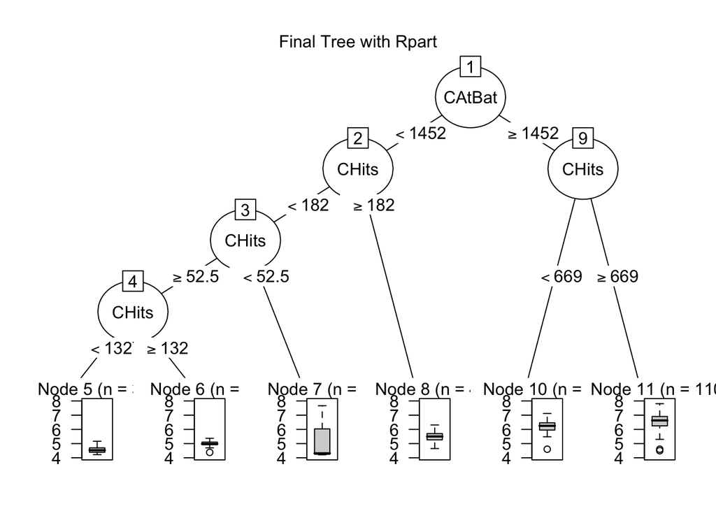

```r
#install.packages('rattle')
#install.packages("RGtk2")
# library(RGtk2)
# library(rattle)  # rattle is needed to produce a neat tree coupled with rpart
library(partykit) # as.party

#fancyRpartPlot(fit.single.rp) # plot method 2  (can't get it work)
plot(as.party(fit.single.rp), main="Final Tree with Rpart") # method 3
```

The plots are only useful for a small tree!

##### Model 2: use all the predictors

```r
fit1.single.full <- tree(LogSalary~., data1)
```

We can control how large a tree we want to build:

- `control=tree.control( minsize = 6, mindev = 0.05))`
- the default `tree.control(nobs, mincut = 5, minsize = 10, mindev = 0.01)`
- `mincut`: min number of obs’n to be included in a child
- `minsize`: number of end nodes
- `mindev`: the dev needs to be reduced by mindev fold within the branch: `dev_new < mindev * dev_parent`

Here is the tree:

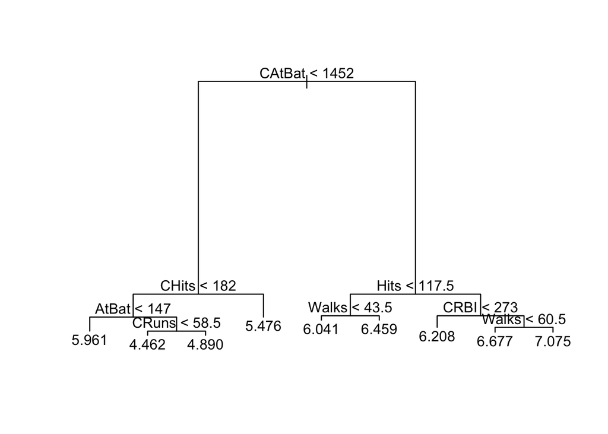

```r
plot(fit1.single.full)
text(fit1.single.full, pretty=0)
```

```r
fit1.single.full$frame
```

```
##       var   n        dev     yval splits.cutleft splits.cutright
## 1  CAtBat 263 207.153733 5.927222          <1452           >1452
## 2   CHits 103  36.219531 5.092883           <182            >182
## 4   AtBat  56  18.359003 4.771243           <147            >147
## 8  <leaf>   5   5.899214 5.960817
## 9   CRuns  51   4.690699 4.654619          <58.5           >58.5
## 18 <leaf>  28   1.019443 4.461532
## 19 <leaf>  23   1.356502 4.889681
## 5  <leaf>  47   5.164546 5.476113
## 3    Hits 160  53.076591 6.464327         <117.5          >117.5
## 6   Walks  70  17.614854 6.154182          <43.5           >43.5
## 12 <leaf>  51  12.698394 6.040604
## 13 <leaf>  19   2.492602 6.459051
## 7    CRBI  90  23.491474 6.705551           <273            >273
## 14 <leaf>  20   4.417880 6.207542
## 15  Walks  70  12.696119 6.847839          <60.5           >60.5
## 30 <leaf>  40   4.708569 6.677344
## 31 <leaf>  30   5.274504 7.075165
```

```r
fit1.single.full.s <- summary(fit1.single.full)
names(fit1.single.full.s)
```

```
## [1] "call"      "type"      "used"      "size"      "df"        "dev"
## [7] "residuals"
```

```r
names(fit1.single.full)
```

```
## [1] "frame"   "where"   "terms"   "call"    "y"       "weights"
```

```r
fit1.single.full.s$dev  # RSS=43.03
```

```
## [1] 43.03165
```

```r
sum((fit1.single.full.s$residuals)^2) # to check the dev is the RSS
```

```
## [1] 43.03165
```

```r
fit1.single.full.s$used # Var's included
```

```
## [1] CAtBat CHits  AtBat  CRuns  Hits   Walks  CRBI
## 20 Levels: <leaf> AtBat Hits HmRun Runs RBI Walks Years CAtBat ... NewLeague
```

7 variables are used:

- `CAtBat`, `CHits`, `AtBat`, `CRuns`, `Hits`, `Walks`, `CRBI`
- There are 9 terminal nodes

```r
fit1.single.full.s$size
```

```
## [1] 9
```

```r
RSS.lm <- (263-8)*((summary(lm(LogSalary~CAtBat+CHits+AtBat+CRuns+Hits+Walks+CRBI, data1)))$sigma)^2
RSS.lm   # Still pretty big 101.5803
```

```
## [1] 101.5803
```

**Question**: do you expect that the testing `RSS(lm)` > `RSS(single tree)` ?

### 2) Bagging: general method

```
Algorithm:
  1) Take B many bootstrap samples
  2) One tree for each B sample
  3) The final predictor = Average of all B  trees
  4) It is a special case for Random Forest
```

- **Pros**: Reduce the var while maintain similar bias.
- **Cons**: The trees are correlated (on higher level).

### 3) Random Forest

```
Algorithm:
  1) Take B many bootstrap samples
  2) Build a deep random tree for each Bootstrap sample by
    * Split only m (mtry) randomly chosen predictors at each split
  3) Bag all the random trees by taking average => prediction of y given x_1,... x_p
  4) Use Out of Bag testing errors to tune mtry!!!!!
```

- **Pros**: Decorrelate the trees - reduce var more
- **Cons**: Tuning parameter `m` is introduced
- `m` too small - miss important var’s
- `m` too large - more cor between trees

Remark: 1) nodesize:5 for reg’s and 1 for classifications 2) when mtry=p (=19), randomForest gives us bagging estimates.

```r
library(randomForest)
```

1. For a fixed mtry

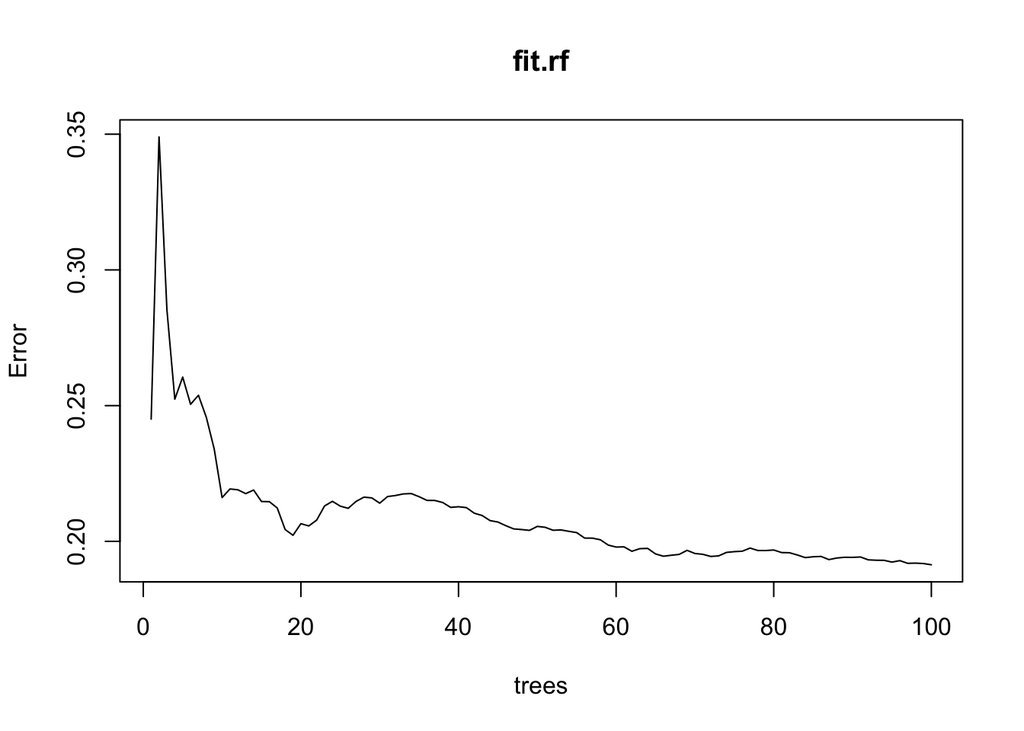

```r
fit.rf <- randomForest(LogSalary~., data1, mtry=6, ntree=100)
plot(fit.rf)  # repeat this and you see variability in the plots why so???
```

```r
str(fit.rf)
```

```
## List of 18
##  $ call           : language randomForest(formula = LogSalary ~ ., data = data1, mtry = 6, ntree = 100)
##  $ type           : chr "regression"
##  $ predicted      : Named num [1:263] 6.21 6.6 6.78 4.73 6.62 ...
##   ..- attr(*, "names")= chr [1:263] "-Alan Ashby" "-Alvin Davis" "-Andre Dawson" "-Andres Galarraga" ...
##  $ mse            : num [1:100] 0.245 0.349 0.285 0.252 0.261 ...
##  $ rsq            : num [1:100] 0.689 0.557 0.638 0.68 0.669 ...
##  $ oob.times      : int [1:263] 36 26 28 42 35 38 40 33 37 45 ...
##  $ importance     : num [1:19, 1] 7.92 8.81 2.69 5.49 5.6 ...
##   ..- attr(*, "dimnames")=List of 2
##   .. ..$ : chr [1:19] "AtBat" "Hits" "HmRun" "Runs" ...
##   .. ..$ : chr "IncNodePurity"
##  $ importanceSD   : NULL
##  $ localImportance: NULL
##  $ proximity      : NULL
##  $ ntree          : num 100
##  $ mtry           : num 6
##  $ forest         :List of 11
##   ..$ ndbigtree    : int [1:100] 181 183 167 177 161 177 175 183 171 187 ...
##   ..$ nodestatus   : int [1:193, 1:100] -3 -3 -3 -3 -3 -3 -3 -1 -3 -3 ...
##   ..$ leftDaughter : int [1:193, 1:100] 2 4 6 8 10 12 14 0 16 18 ...
##   ..$ rightDaughter: int [1:193, 1:100] 3 5 7 9 11 13 15 0 17 19 ...
##   ..$ nodepred     : num [1:193, 1:100] 5.95 5.07 6.5 4.67 5.44 ...
##   ..$ bestvar      : int [1:193, 1:100] 11 8 1 5 2 12 11 0 5 16 ...
##   ..$ xbestsplit   : num [1:193, 1:100] 204.5 689 369 5.5 115.5 ...
##   ..$ ncat         : Named int [1:19] 1 1 1 1 1 1 1 1 1 1 ...
##   .. ..- attr(*, "names")= chr [1:19] "AtBat" "Hits" "HmRun" "Runs" ...
##   ..$ nrnodes      : int 193
##   ..$ ntree        : num 100
##   ..$ xlevels      :List of 19
##   .. ..$ AtBat    : num 0
##   .. ..$ Hits     : num 0
##   .. ..$ HmRun    : num 0
##   .. ..$ Runs     : num 0
##   .. ..$ RBI      : num 0
##   .. ..$ Walks    : num 0
##   .. ..$ Years    : num 0
##   .. ..$ CAtBat   : num 0
##   .. ..$ CHits    : num 0
##   .. ..$ CHmRun   : num 0
```

[output cut: 14 more lines]

```
##  $ terms          :Classes 'terms', 'formula'  language LogSalary ~ AtBat + Hits + HmRun + Runs + RBI + Walks + Years + CAtBat +      CHits + CHmRun + CRuns + CRBI + CWalks + League + Division + PutOuts +  ...
##   .. ..- attr(*, "variables")= language list(LogSalary, AtBat, Hits, HmRun, Runs, RBI, Walks, Years, CAtBat,      CHits, CHmRun, CRuns, CRBI, CWalks, League, Division, PutOuts,  ...
##   .. ..- attr(*, "factors")= int [1:20, 1:19] 0 1 0 0 0 0 0 0 0 0 ...
##   .. .. ..- attr(*, "dimnames")=List of 2
##   .. .. .. ..$ : chr [1:20] "LogSalary" "AtBat" "Hits" "HmRun" ...
##   .. .. .. ..$ : chr [1:19] "AtBat" "Hits" "HmRun" "Runs" ...
##   .. ..- attr(*, "term.labels")= chr [1:19] "AtBat" "Hits" "HmRun" "Runs" ...
##   .. ..- attr(*, "order")= int [1:19] 1 1 1 1 1 1 1 1 1 1 ...
##   .. ..- attr(*, "intercept")= num 0
##   .. ..- attr(*, "response")= int 1
##   .. ..- attr(*, ".Environment")=<environment: R_GlobalEnv>
##   .. ..- attr(*, "predvars")= language list(LogSalary, AtBat, Hits, HmRun, Runs, RBI, Walks, Years, CAtBat,      CHits, CHmRun, CRuns, CRBI, CWalks, League, Division, PutOuts,  ...
##   .. ..- attr(*, "dataClasses")= Named chr [1:20] "numeric" "numeric" "numeric" "numeric" ...
##   .. .. ..- attr(*, "names")= chr [1:20] "LogSalary" "AtBat" "Hits" "HmRun" ...
##  - attr(*, "class")= chr [1:2] "randomForest.formula" "randomForest"
```

default settings: + `mtry`=p/3, (sqrt(p) in classification tree) + Bootstrap size `B`=`ntree`=500 + when `mtry`=`p`=19, randomForest gives us bagging estimates. + nodesize:5 for reg’s, and 1 for classifications.

Based on the 100 random trees, we get hat y= ave (all 100 trees). How does it perform?

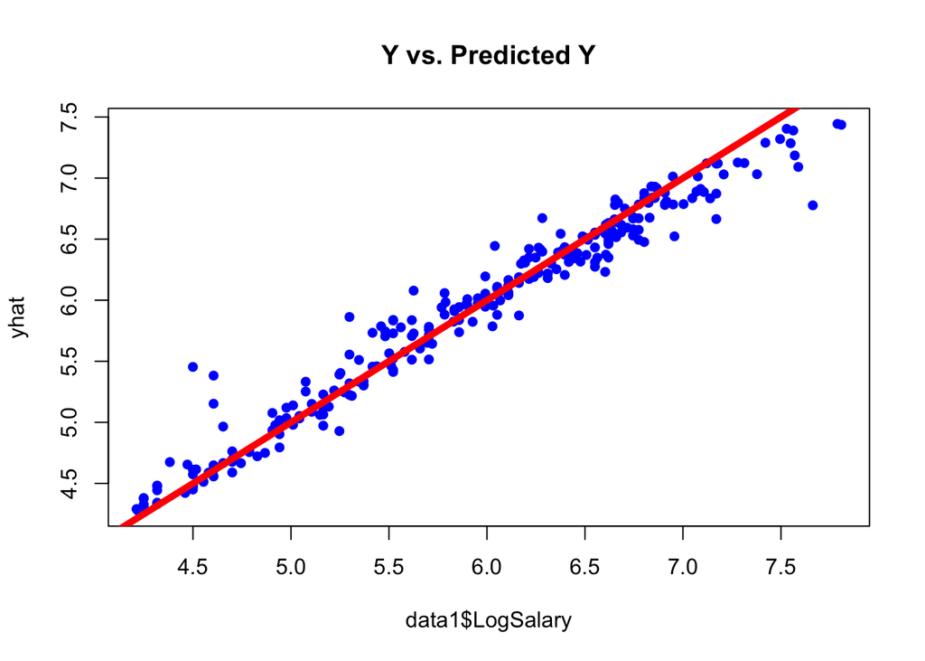

```r
yhat <- predict(fit.rf, data1)   # predicted values we use

plot(data1$LogSalary, yhat, pch=16,  # add a 45 degree line:looks very good!
     main="Y vs. Predicted Y", col="blue")
abline(0, 1, lwd=5, col="red")
```

```r
mse.train <- mean((data1$LogSalary-yhat)^2)  # RSS= sum((data1$LogSalary-yhat)^2)
mse.train      # Training mse approx. .03!!!
```

```
## [1] 0.03422456
```

```r
mse.oob <- mean((data1$LogSalary-fit.rf$predicted)^2)  #OOB testing error
mse.oob        # about .18
```

```
## [1] 0.1913718
```

2. Zoom in to a RF estimate

```r
fit.rf <- randomForest(LogSalary~., data1, mtry=10, ntree=100)
#fit.rf <- randomForest(LogSalary~., data1, mtry=10, ntree=2)
str(fit.rf)
```

```
## List of 18
##  $ call           : language randomForest(formula = LogSalary ~ ., data = data1, mtry = 10, ntree = 100)
##  $ type           : chr "regression"
##  $ predicted      : Named num [1:263] 6.12 6.46 6.82 4.71 6.58 ...
##   ..- attr(*, "names")= chr [1:263] "-Alan Ashby" "-Alvin Davis" "-Andre Dawson" "-Andres Galarraga" ...
##  $ mse            : num [1:100] 0.312 0.319 0.298 0.321 0.279 ...
##  $ rsq            : num [1:100] 0.604 0.595 0.621 0.593 0.646 ...
##  $ oob.times      : int [1:263] 37 35 41 33 33 46 33 38 35 34 ...
##  $ importance     : num [1:19, 1] 7.4 9.51 2.15 4.28 4.67 ...
##   ..- attr(*, "dimnames")=List of 2
##   .. ..$ : chr [1:19] "AtBat" "Hits" "HmRun" "Runs" ...
##   .. ..$ : chr "IncNodePurity"
##  $ importanceSD   : NULL
##  $ localImportance: NULL
##  $ proximity      : NULL
##  $ ntree          : num 100
##  $ mtry           : num 10
##  $ forest         :List of 11
##   ..$ ndbigtree    : int [1:100] 163 175 189 177 185 173 179 171 175 175 ...
##   ..$ nodestatus   : int [1:191, 1:100] -3 -3 -3 -1 -3 -3 -3 -3 -3 -3 ...
##   ..$ leftDaughter : int [1:191, 1:100] 2 4 6 0 8 10 12 14 16 18 ...
##   ..$ rightDaughter: int [1:191, 1:100] 3 5 7 0 9 11 13 15 17 19 ...
##   ..$ nodepred     : num [1:191, 1:100] 5.97 5.06 6.43 7.24 5.01 ...
##   ..$ bestvar      : int [1:191, 1:100] 9 11 2 0 11 2 8 8 12 2 ...
##   ..$ xbestsplit   : num [1:191, 1:100] 331 11 118 0 78 ...
##   ..$ ncat         : Named int [1:19] 1 1 1 1 1 1 1 1 1 1 ...
##   .. ..- attr(*, "names")= chr [1:19] "AtBat" "Hits" "HmRun" "Runs" ...
##   ..$ nrnodes      : int 191
##   ..$ ntree        : num 100
##   ..$ xlevels      :List of 19
##   .. ..$ AtBat    : num 0
##   .. ..$ Hits     : num 0
##   .. ..$ HmRun    : num 0
##   .. ..$ Runs     : num 0
##   .. ..$ RBI      : num 0
##   .. ..$ Walks    : num 0
##   .. ..$ Years    : num 0
##   .. ..$ CAtBat   : num 0
##   .. ..$ CHits    : num 0
##   .. ..$ CHmRun   : num 0
```

[output cut: 14 more lines]

```
##  $ terms          :Classes 'terms', 'formula'  language LogSalary ~ AtBat + Hits + HmRun + Runs + RBI + Walks + Years + CAtBat +      CHits + CHmRun + CRuns + CRBI + CWalks + League + Division + PutOuts +  ...
##   .. ..- attr(*, "variables")= language list(LogSalary, AtBat, Hits, HmRun, Runs, RBI, Walks, Years, CAtBat,      CHits, CHmRun, CRuns, CRBI, CWalks, League, Division, PutOuts,  ...
##   .. ..- attr(*, "factors")= int [1:20, 1:19] 0 1 0 0 0 0 0 0 0 0 ...
##   .. .. ..- attr(*, "dimnames")=List of 2
##   .. .. .. ..$ : chr [1:20] "LogSalary" "AtBat" "Hits" "HmRun" ...
##   .. .. .. ..$ : chr [1:19] "AtBat" "Hits" "HmRun" "Runs" ...
##   .. ..- attr(*, "term.labels")= chr [1:19] "AtBat" "Hits" "HmRun" "Runs" ...
##   .. ..- attr(*, "order")= int [1:19] 1 1 1 1 1 1 1 1 1 1 ...
##   .. ..- attr(*, "intercept")= num 0
##   .. ..- attr(*, "response")= int 1
##   .. ..- attr(*, ".Environment")=<environment: R_GlobalEnv>
##   .. ..- attr(*, "predvars")= language list(LogSalary, AtBat, Hits, HmRun, Runs, RBI, Walks, Years, CAtBat,      CHits, CHmRun, CRuns, CRBI, CWalks, League, Division, PutOuts,  ...
##   .. ..- attr(*, "dataClasses")= Named chr [1:20] "numeric" "numeric" "numeric" "numeric" ...
##   .. .. ..- attr(*, "names")= chr [1:20] "LogSalary" "AtBat" "Hits" "HmRun" ...
##  - attr(*, "class")= chr [1:2] "randomForest.formula" "randomForest"
```

1. Where is cross validation testing error? It is cleverly replaced by OOB mse

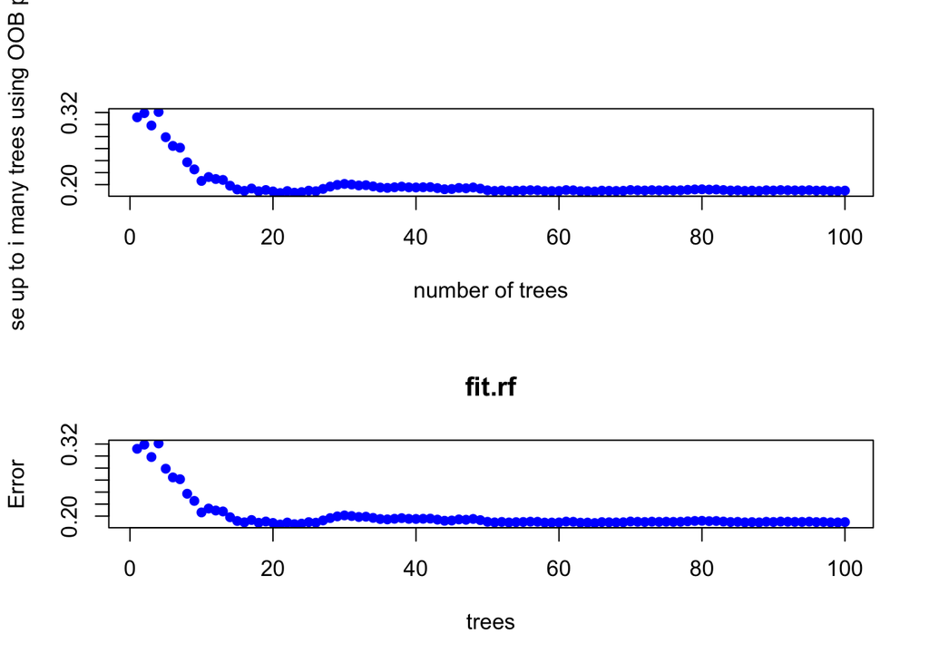

```r
par(mfrow=c(2,1))
plot(fit.rf$mse, xlab="number of trees", col="blue",
     ylab="ave mse up to i many trees using OOB predicted",
     pch=16) # We only need about 100 trees for this
# We get the above plot by
plot(fit.rf, type="p", pch=16,col="blue" )
```

```r
par(mfrow=c(1,1))
```

2. OOB’s are used

```r
fit.rf$oob.times  # how many times each obs'n belong to OOB. We expect to see 1/e=1/3 (.37)
```

```
##   [1] 37 35 41 33 33 46 33 38 35 34 37 38 41 39 36 38 36 38 37 35 35 39 29
##  [24] 41 47 42 34 39 31 38 33 34 33 46 35 40 35 47 36 39 34 29 35 40 45 30
##  [47] 36 35 35 39 38 35 35 37 37 37 36 33 41 38 35 35 40 33 36 36 39 41 32
##  [70] 33 40 40 37 36 45 41 36 38 32 38 40 41 48 48 35 40 39 29 32 36 35 46
##  [93] 43 28 28 33 31 34 38 37 37 36 31 36 35 33 28 40 38 44 37 41 38 39 34
## [116] 37 34 43 39 37 44 46 49 36 31 37 33 38 47 40 37 32 37 43 37 42 40 32
## [139] 44 29 30 34 41 39 42 39 36 37 28 31 44 31 36 44 41 34 41 32 39 32 36
## [162] 36 38 31 35 32 41 29 35 41 35 39 37 32 31 38 34 29 32 31 36 48 30 29
## [185] 35 40 35 44 35 34 39 33 39 41 43 35 35 41 32 43 37 34 33 31 36 37 35
## [208] 35 32 35 36 43 40 35 32 34 33 28 42 45 43 31 35 36 33 36 31 33 45 37
## [231] 37 34 37 35 34 30 38 38 35 31 34 42 38 40 41 40 35 30 37 32 33 36 42
## [254] 34 39 35 40 38 45 35 34 32 34
```

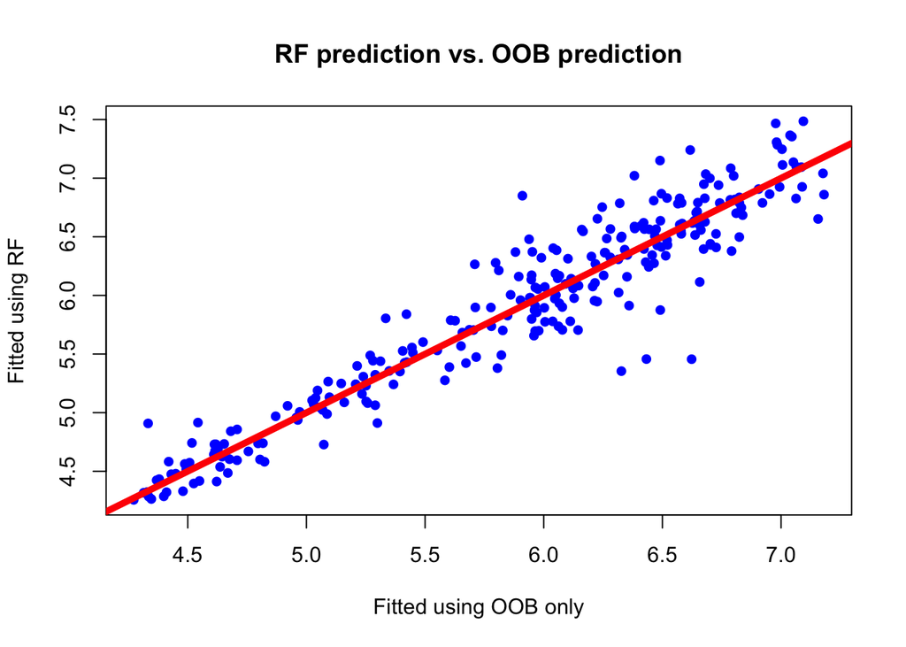

```r
#   fit.rf$mse is OOB testing errors = mse of only using the OOB fitted values up to tree number
#   fit.rf$predicted is obtained only using the OOB obs'n

# fit.rf$predicted[]   # predicted values based on all OOB values. we use this to estimate the mse which is approx. the testing error
# predict(fit.rf, data1)  # predicted values based on the RF. this will be sued for predictions.

plot(fit.rf$predicted,predict(fit.rf, data1), pch=16, col="blue",
     main="RF prediction vs. OOB prediction",
     xlab="Fitted using OOB only",
     ylab="Fitted using RF")
abline(0, 1, col="red", lwd=5)   # They differ but not by too much.
```

2. Ready to tune `mtry` and `B`=number of the trees in the bag
3. `ntree` effect: given mtry and ntree, we see the effect of ntree first

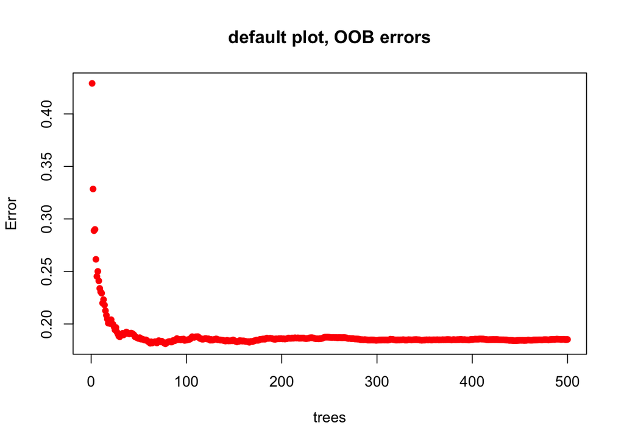

```r
fit.rf <- randomForest(LogSalary~., data1, mtry=10, ntree=500)
plot(fit.rf, col="red", pch=16, type="p", main="default plot, OOB errors")
```

We may need 250 trees to settle the OOB testing errors

2. The effect of `mtry`: the number of random split at each leaf

Now we fix `ntree`=250, We only want to compare the OOB mse[250] to see the mtry effects.

Here we loop `mtry` from 1 to 19 and return the testing OOB errors

```r
par(mfrow=c(3,1))
rf.error.p <- 1:19  # set up a vector of length 19
for (p in 1:19)  # repeat the following code inside { } 19 times
{
  fit.rf <- randomForest(LogSalary~., data1, mtry=p, ntree=250)
  #plot(fit.rf, col= p, lwd = 3)
  rf.error.p[p] <- fit.rf$mse[250]  # collecting oob mse based on 250 trees
}
rf.error.p   # oob mse returned: should be a vector of 19
```

```
##  [1] 0.2141751 0.1895088 0.1838257 0.1796597 0.1811641 0.1841309 0.1802893
##  [8] 0.1809996 0.1872005 0.1848433 0.1889867 0.1848192 0.1860355 0.1876580
## [15] 0.1910811 0.1890605 0.1830303 0.1837231 0.1882445
```

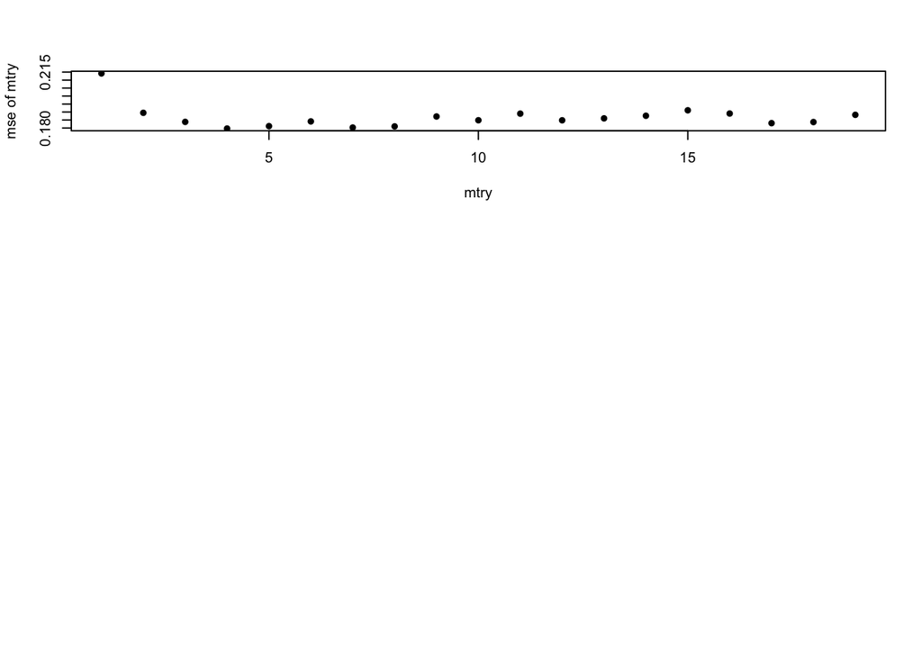

```r
plot(1:19, rf.error.p, pch=16,
     xlab="mtry",
     ylab="mse of mtry")
```

Run above loop a few time, it is not very stable.

**Notice** 1) mtry = 1 is clearly not a good choice. 2) The recommended mtry for reg trees are mtry=p/3=19/3 about 6 or 7. Seems to agree with this example. Are you convinced with p/3?

We should treat `mtry` to be a tuning parameter!!!!!!!!

3. The final fit: we take `mtry`=6

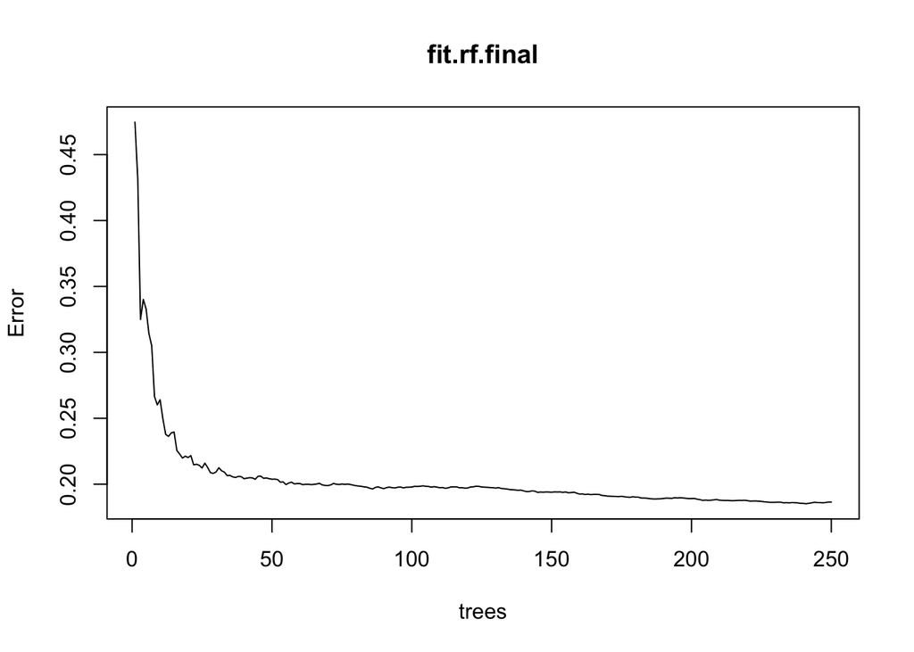

```r
fit.rf.final <- randomForest(LogSalary~., data1, mtry=6, ntree=250)
plot(fit.rf.final)
```

```r
fit.rf.final$mse[250] # approx is same as the testing error
```

```
## [1] 0.1864066
```

4. Prediction

```r
person <- data1[1, ]   # Let's predict rownames(data1)[1]: "-Alan Ashby"
fit.person <- predict(fit.rf.final, person)
fit.person # the fitted salary in log scale is 6.196343 (may not be the same each time we run the rf, why?)
```

```
## -Alan Ashby
##     6.12564
```

```r
# -Alan Ashby
# 6.170148

# Alan Ashby's true log sal
data1$LogSalary[1]
```

```
## [1] 6.163315
```

```r
# [1] 6.163315
```

End of randomForest in regressions.

### 4) Appendices

### Appendix I: Testing errors vs. OOB testing erros

We could also get testing errors w/o using OOB idea The following code verify that OOB errors seem to be a good estimate of testing errors.

```r
n <- nrow(data1)
#set.seed(1)
train.index <- sample(n, n*3/4) # we use about 3/4 of the subjects as the training data.
train.index
```

```
##   [1]  52 137  71 153 122  81 163 170 126 138 120  96 187 240  68  14 125
##  [18] 238 241 112  47 228 101 114  10 229  55 242  98 237 212 235 225 255
##  [35]  49 196 158  39  26 205 226 116 244 135  33  56  28 139 227 261 214
##  [52] 207 262 115 222  43  60 109 250  84 184  93  51 140 260 230 145  78
##  [69]  50 201  17  65 119 183  15 194  36 193 182  80 246 155   2 231 164
##  [86] 215  35   1 185 144 247 151  48  92 157 143 108  85 107 136 118 186
## [103]  31  25 162   5  90 124 198 257 102 245 123  38 106 204  34 105  30
## [120]  97 141  83 110  59 263 104 216  69 236 180 243 253 127 149 233 148
## [137]  22 167  70  74  82 254 147  19 132  77 100   3  23 159 177 203  18
## [154] 258   4 256 219 209  32  27 217  66 161 208 171  12 192 168  72   7
## [171]  61 128 232  99  87 174  64 223  44  63  13 178 103  41 121  86 189
## [188] 218  54  58 134 172  57 213 129 146 224
```

```r
data.train <- data1[train.index,]
data.test <- data1[-train.index, ]

fit.rf.train <- randomForest(LogSalary~., data.train,  mtry=6, ntree=500)
```

This will output the oob errors

To get testing error:

```r
fit.rf.testing <- randomForest(LogSalary~., data.train, xtest=data.test[, -20],
                          ytest=data.test[,20], mtry=6, ntree=500)
# fit.rf.testing$mse
```

This will output the testing errors directly

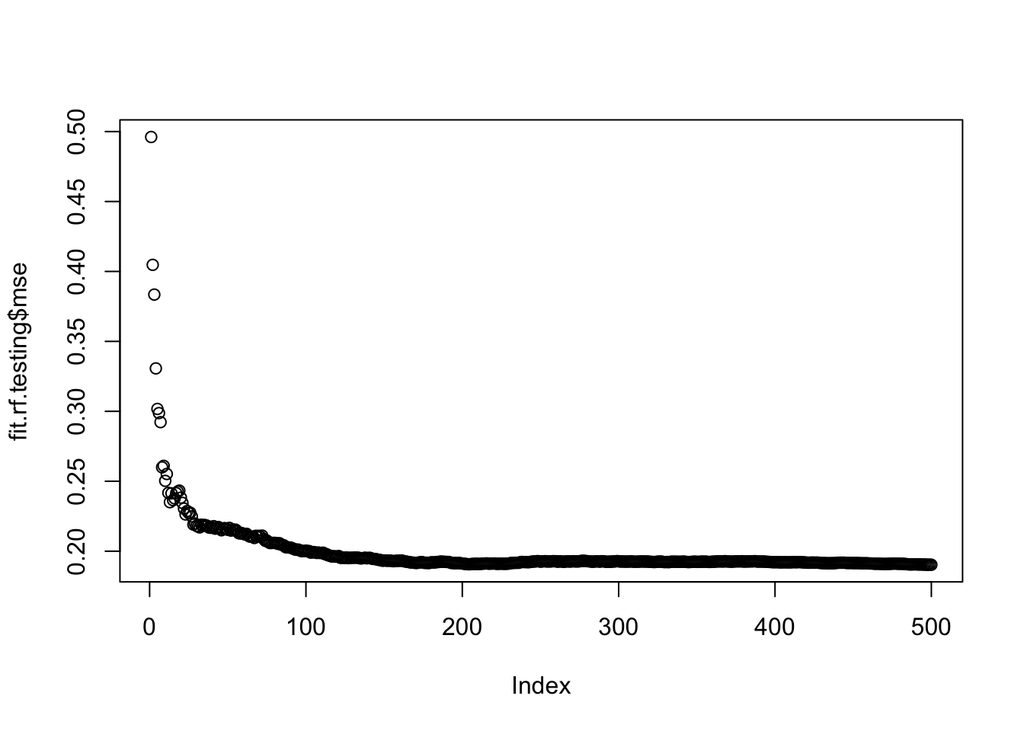

```r
plot(fit.rf.testing$mse)
```

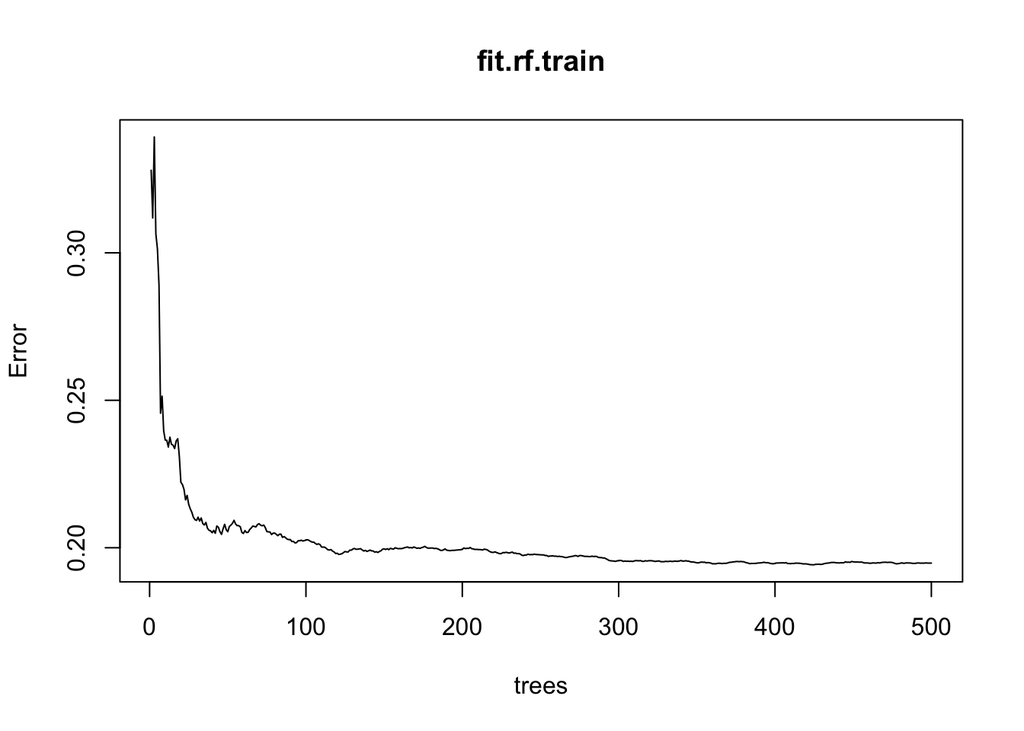

```r
plot(fit.rf.train) # when xtest and ytest are given, the output will be for testing data, like y, mse, etc
```

The testing errors seem to agree with what we found using OOB errors.

Let’s put testing errors and OOB errors together

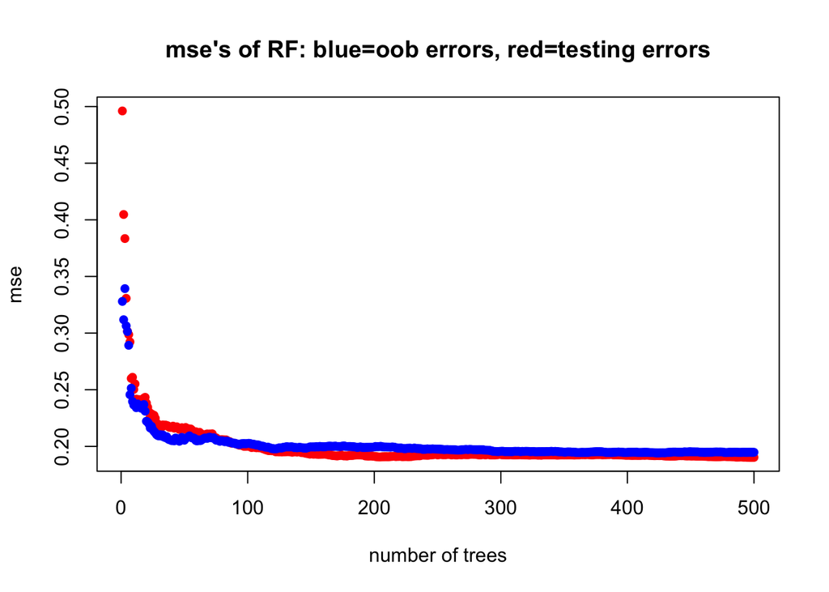

```r
plot(1:500, fit.rf.testing$mse, col="red", pch=16,
     xlab="number of trees",
     ylab="mse",
     main="mse's of RF: blue=oob errors, red=testing errors")
points(1:500, fit.rf.train$mse, col="blue", pch=16)
```

OOB errors seem to do ok to estimate the testing errors!!! Not bad at all…..

### Appendix II: Effects for different Bootstrap samples on a single tree

- Trees built by resampling the data through BOOTSTRAP method
- Take a bootstrap sample and exam the tree built by the sample
1. About 2/3 of the original subjects are chosen in each Bootstrap sample
2. The trees are different
3. mse changes a lot

```r
RSS <- 0  # initial values
n.unique <- 0
n <- nrow(data1); K <- 20
# for (i in 1:K)
# {
#   index1 <- sample(n, n, replace=TRUE)
#   Sample1 <- data1[index1, ]               # Take a bootstrap sample
#   fit1.boot <- tree(LogSalary~., Sample1)  # Get a tree fit
#   RSS[i] <- summary(fit1.boot)$dev  # output RSS for each bootstrap tree
#   plot(fit1.boot,
#        main="Trees with a Bootstrap sample")
#   text(fit1.boot, pretty=0)
#   n.unique[i] <- length(unique(index1))
#   Sys.sleep(2)                        # Pause for 2 seconds before running for next round
# }
#
# hist(RSS, breaks=30,
#      col="blue",
#      main="RSS from different Bootstrap trees")
#
#
# hist(n.unique, breaks=30,
#      col="red",
#      main="number of unique subjects included in each Bootstrap sample")
#
# hist(n-n.unique, breaks=30,
#      col="green",
#      main="number of OOB subjects not included in each Bootstrap sample")
```

```r
RSS <- 0  # initial values
n.unique <- 0
n <- nrow(data1); K <- 20
# for (i in 1:K)
# {
#   index1 <- sample(n, n, replace=TRUE)
#   Sample1 <- data1[index1, ]               # Take a bootstrap sample
#   fit1.boot <- tree(LogSalary~., Sample1)  # Get a tree fit
#   RSS[i] <- summary(fit1.boot)$dev  # output RSS for each bootstrap tree
#   plot(fit1.boot,
#        main="Trees with a Bootstrap sample")
#   text(fit1.boot, pretty=0)
#   n.unique[i] <- length(unique(index1))
#   Sys.sleep(2)                        # Pause for 2 seconds before running for next round
# }
#
# hist(RSS, breaks=30,
#      col="blue",
#      main="RSS from different Bootstrap trees")
#
#
# hist(n.unique, breaks=30,
#      col="red",
#      main="number of unique subjects included in each Bootstrap sample")
#
# hist(n-n.unique, breaks=30,
#      col="green",
#      main="number of OOB subjects not included in each Bootstrap sample")
```

A single tree

```r
fit.single <- randomForest(LogSalary~., data1, mtry=19, ntree=1)
```

Bagging with 100 Bootstrap samples

```r
fit.bagging <- randomForest(LogSalary~., data1, mtry=19, ntree=100)
```

Random Forest

```r
fit.rf <- randomForest(LogSalary~., data1, mtry=6, ntree=100)
```

Compare performance among the three methods graphically:

[figure not shown]

```r
par(mfrow=c(3,1))
ylim.0 <- c(3.5, 7.5)
plot(data1$LogSalary, predict(fit.single, data1), pch=16,  # add a 45 degree line:looks very good!
     ylim=ylim.0,
     main="A single tree", col="blue")
abline(0, 1, lwd=5, col="red")

plot(data1$LogSalary, predict(fit.bagging), pch=16,  # add a 45 degree line:looks very good!
     ylim=ylim.0,
     main="A bagging tree, 100 trees", col="blue")
abline(0, 1, lwd=5, col="red")

plot(data1$LogSalary, predict(fit.rf), pch=16,  # add a 45 degree line:looks very good!
     ylim=ylim.0,
     main="A RF tree, mtry=10, 100 trees", col="blue")
abline(0, 1, lwd=5, col="red")
```

```r
par(mfrow=c(1,1))
```

Testing errors through OOB among the three:

```r
c(fit.single$mse, fit.bagging$mse[100], fit.rf$mse[100])
```

```
## [1] 0.3484307 0.1909778 0.1791631
```

RF is the best (??) but it should have performed much better than a bagging estimate. Are the three mse’s comparable????

#### 5) Boosting

```r
library(gbm) # boosting machine
data1 <- data1[sample(nrow(data1)), ] # make sure the row number plays no row!
```

1. Boosting in action

```r
ntree <- 200
fit.boost <- gbm(LogSalary ~., data = data1, distribution = "gaussian", n.trees = ntree, interaction.depth = 2,
                 train.fraction = .7)
```

**arguments:**

- `distribution` = “gaussian” for continuous response and “bernoulli”/“multinomial” for two/more two/more classes.
- `interation.depth` = depth of the tree, the number of splits. d=1 (default) is a stump tree, i.e. only one split
- `n.trees` = number of the trees to be updated, default=100
- `train.fraction` = training set, the error will be testing error with the remaining data. **Caution**: the first train.fraction of the data will be used as a training set
  - Make sure the data is in a random order.
- `bag.fraction` = fraction of the training data, fraction of the data used for training the next tree default set at .5
- `shrinkage` = 0.001 set as default.

##### Output

```r
names(fit.boost)
```

```
##  [1] "initF"             "fit"               "train.error"
##  [4] "valid.error"       "oobag.improve"     "trees"
##  [7] "c.splits"          "bag.fraction"      "distribution"
## [10] "interaction.depth" "n.minobsinnode"    "num.classes"
## [13] "n.trees"           "nTrain"            "train.fraction"
## [16] "response.name"     "shrinkage"         "var.levels"
## [19] "var.monotone"      "var.names"         "var.type"
## [22] "verbose"           "data"              "Terms"
## [25] "cv.folds"          "call"              "m"
```

```r
fit.boost$fit # hat y
```

```
##   [1] 6.061585 6.018072 5.969448 6.108024 5.771590 5.777031 6.029070
##   [8] 6.036371 5.776157 6.101289 6.089160 5.771590 5.810338 6.107367
##  [15] 6.006834 5.998677 6.065525 5.771590 6.082309 6.084142 6.032857
##  [22] 6.048943 5.998730 6.000827 6.037010 6.044589 6.109453 6.002217
##  [29] 5.771590 5.889585 5.771590 6.045733 6.061546 6.005539 6.036371
##  [36] 5.955878 6.049638 5.811923 5.819694 6.040592 5.933124 6.067430
##  [43] 5.774089 6.047675 6.031125 6.012951 6.106004 5.895306 5.956695
##  [50] 6.062009 5.771590 6.026790 5.771590 6.064688 5.989903 6.102559
##  [57] 6.074051 5.771590 5.906268 5.788871 6.060569 5.977285 5.771590
##  [64] 6.068299 5.810316 6.050879 6.090685 5.784267 6.014043 6.109541
##  [71] 6.054438 6.054479 5.771590 6.097684 6.074318 6.029275 5.983068
##  [78] 6.097276 5.798216 6.045206 6.065728 6.083043 6.056283 5.776292
##  [85] 5.784933 5.824923 6.065019 5.771590 5.840583 5.810302 6.020712
##  [92] 6.044233 6.059005 5.818199 5.907358 5.851950 6.046073 6.038109
##  [99] 6.071373 5.783703 5.771590 6.105824 6.061059 6.017919 6.036371
```

[output cut: 23 more lines]

```r
fit.boost$train.error # training errors
```

```
##   [1] 0.8309963 0.8298210 0.8289446 0.8280479 0.8270517 0.8259314 0.8248155
##   [8] 0.8238220 0.8228385 0.8217744 0.8207693 0.8197522 0.8187383 0.8177531
##  [15] 0.8166742 0.8155812 0.8145005 0.8135124 0.8124193 0.8114576 0.8104824
##  [22] 0.8094010 0.8083378 0.8073930 0.8062592 0.8054320 0.8043339 0.8034469
##  [29] 0.8025349 0.8014716 0.8005254 0.7994900 0.7983382 0.7973388 0.7963825
##  [36] 0.7953387 0.7943964 0.7933519 0.7923410 0.7913367 0.7903027 0.7893561
##  [43] 0.7884156 0.7874016 0.7863916 0.7854172 0.7844025 0.7833972 0.7824389
##  [50] 0.7814455 0.7804693 0.7794693 0.7784959 0.7776552 0.7767323 0.7758314
##  [57] 0.7749008 0.7740061 0.7730058 0.7720397 0.7711688 0.7702923 0.7692490
##  [64] 0.7682905 0.7672932 0.7664192 0.7656304 0.7647106 0.7637502 0.7629487
##  [71] 0.7620070 0.7609153 0.7600757 0.7591870 0.7583651 0.7574286 0.7566308
##  [78] 0.7556242 0.7547269 0.7537493 0.7529322 0.7521132 0.7512697 0.7503300
##  [85] 0.7494379 0.7484587 0.7475046 0.7466127 0.7456920 0.7449126 0.7440382
##  [92] 0.7432002 0.7424049 0.7414615 0.7404675 0.7396173 0.7387090 0.7378182
##  [99] 0.7370760 0.7361792 0.7353884 0.7345195 0.7336106 0.7328104 0.7319126
## [106] 0.7311338 0.7302456 0.7293892 0.7285257 0.7276669 0.7268301 0.7260540
## [113] 0.7251450 0.7242371 0.7233162 0.7223847 0.7215299 0.7206447 0.7197724
## [120] 0.7188199 0.7181099 0.7173295 0.7165129 0.7157050 0.7148518 0.7139617
## [127] 0.7131521 0.7123296 0.7114360 0.7107327 0.7098420 0.7090319 0.7081817
## [134] 0.7073528 0.7064619 0.7056406 0.7048155 0.7040034 0.7031372 0.7023461
## [141] 0.7013589 0.7006690 0.6998208 0.6989636 0.6981574 0.6973541 0.6965512
## [148] 0.6957864 0.6950606 0.6941693 0.6933377 0.6925019 0.6916923 0.6908981
## [155] 0.6900881 0.6893005 0.6884097 0.6875613 0.6868526 0.6860798 0.6852416
## [162] 0.6844126 0.6836381 0.6828994 0.6820407 0.6812855 0.6805093 0.6797584
## [169] 0.6789775 0.6782109 0.6774982 0.6766865 0.6758003 0.6750199 0.6742232
## [176] 0.6733735 0.6726671 0.6719066 0.6711550 0.6705373 0.6697881 0.6690101
## [183] 0.6681482 0.6673405 0.6665463 0.6657740 0.6650164 0.6643059 0.6635292
## [190] 0.6627267 0.6620302 0.6612123 0.6605088 0.6597369 0.6589123 0.6581313
## [197] 0.6575086 0.6567552 0.6560891 0.6553745
```

```r
fit.boost$valid.error # testing errors if train.fraction is given
```

```
##   [1] 0.6867149 0.6856675 0.6849026 0.6840811 0.6831924 0.6821616 0.6811249
##   [8] 0.6802591 0.6793649 0.6784369 0.6775464 0.6766371 0.6757713 0.6749113
##  [15] 0.6739163 0.6729563 0.6720235 0.6711631 0.6700980 0.6692333 0.6683347
##  [22] 0.6673552 0.6664318 0.6655671 0.6645055 0.6637358 0.6627455 0.6620102
##  [29] 0.6611901 0.6602686 0.6594545 0.6585492 0.6575418 0.6566725 0.6558588
##  [36] 0.6549039 0.6540750 0.6530356 0.6520517 0.6511908 0.6502923 0.6494855
##  [43] 0.6486578 0.6477709 0.6468393 0.6459560 0.6450776 0.6441952 0.6433867
##  [50] 0.6424520 0.6416409 0.6407683 0.6400072 0.6392740 0.6384797 0.6377166
##  [57] 0.6369072 0.6361869 0.6353124 0.6344515 0.6337078 0.6328678 0.6318722
##  [64] 0.6310431 0.6300980 0.6293120 0.6285760 0.6277900 0.6268855 0.6261335
##  [71] 0.6253220 0.6243855 0.6236637 0.6228549 0.6221584 0.6213144 0.6205748
##  [78] 0.6197057 0.6188580 0.6179413 0.6172260 0.6164740 0.6157057 0.6149246
##  [85] 0.6140629 0.6131933 0.6123389 0.6115876 0.6106834 0.6099493 0.6090983
##  [92] 0.6083813 0.6076563 0.6068326 0.6059068 0.6051898 0.6044434 0.6036272
##  [99] 0.6028039 0.6019142 0.6012345 0.6004889 0.5996459 0.5989611 0.5981799
## [106] 0.5974803 0.5967003 0.5959243 0.5951404 0.5943881 0.5935915 0.5928638
## [113] 0.5921109 0.5913365 0.5905263 0.5897432 0.5889960 0.5882614 0.5875199
## [120] 0.5867164 0.5859863 0.5852718 0.5845389 0.5838103 0.5830168 0.5822282
## [127] 0.5815172 0.5808225 0.5800475 0.5794174 0.5786431 0.5779531 0.5772052
## [134] 0.5764539 0.5756740 0.5749617 0.5742426 0.5735435 0.5726965 0.5719895
## [141] 0.5711334 0.5705305 0.5698143 0.5689876 0.5682487 0.5675481 0.5668287
## [148] 0.5662066 0.5655734 0.5648468 0.5640784 0.5633700 0.5626487 0.5618724
## [155] 0.5611893 0.5604674 0.5597028 0.5589481 0.5583587 0.5576802 0.5569448
## [162] 0.5562505 0.5555992 0.5549798 0.5543142 0.5536670 0.5529918 0.5523053
## [169] 0.5516479 0.5509072 0.5502903 0.5495990 0.5488353 0.5481613 0.5474989
## [176] 0.5467271 0.5461147 0.5454444 0.5447617 0.5442924 0.5436617 0.5429698
## [183] 0.5421984 0.5414352 0.5407331 0.5400717 0.5393468 0.5386902 0.5379965
## [190] 0.5373266 0.5367076 0.5360754 0.5354367 0.5347742 0.5340346 0.5333668
## [197] 0.5328416 0.5321713 0.5316595 0.5310686
```

```r
yhat <- predict(fit.boost, newdata = data1, n.trees = ntree) # prediction, in this case it is the same as fit.boost$fit
```

2. Tune number of trees needed by minimizing the testing errors

Investigate the testing/training errors vs. number of iterations We may use: `gbm.perf(object, plot.it = TRUE, method="test")`

**Remember that the training data will be the first 80% rows.**

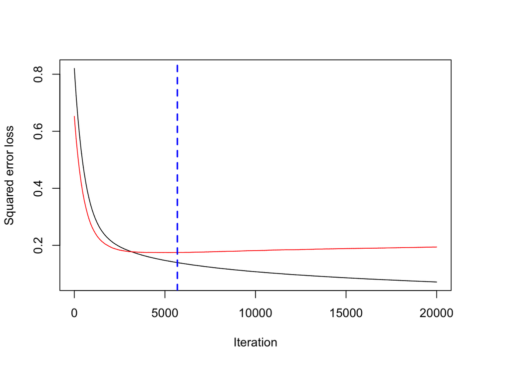

```
## [1] 5687
```

```r
ntree <- 20000
fit.boost <- gbm(LogSalary~., data = data1, distribution = "gaussian", n.trees = ntree, interaction.depth = 2,
                 train.fraction = .8)
gbm.perf(fit.boost, method ="test")
```

Output the optimal number of trees by min the testing errors. + red: `fit.boost$valid.error` (testing errors) + black: `fit.boost$train.error` (training errors)

Notice the testing errors are smaller than that of training error for many iterations.

The above plots are same as:

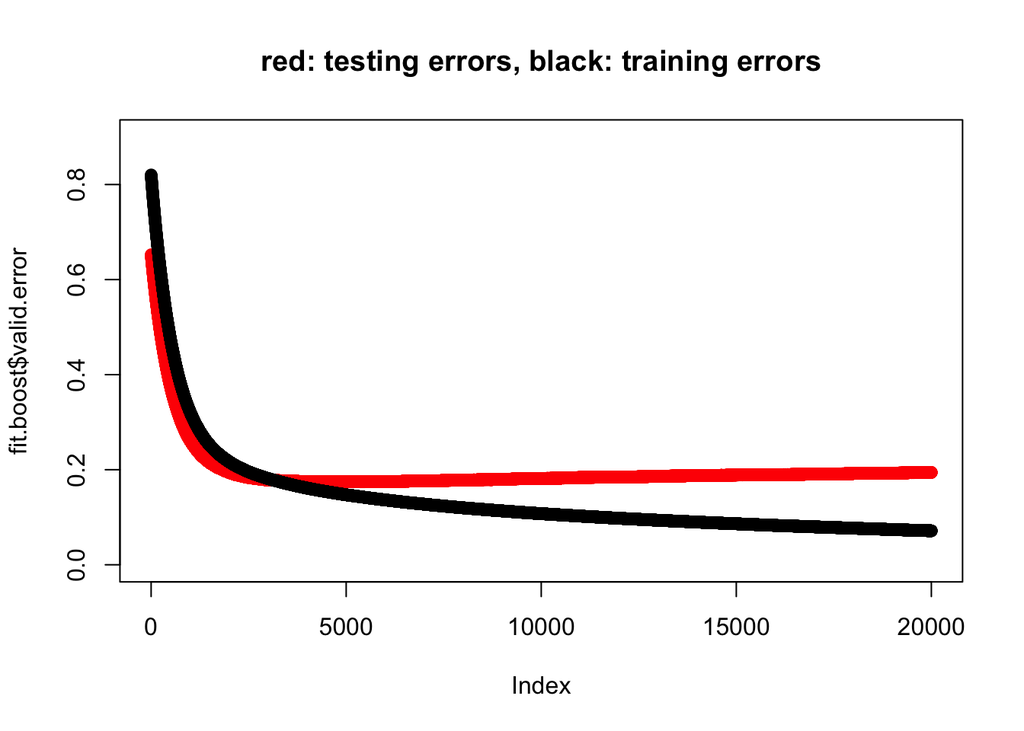

```r
plot(fit.boost$valid.error, col= "red",
     main="red: testing errors, black: training errors",
     ylim = c(0, .9))
points(fit.boost$train.error, col="black")
```

We now use the optimal number of trees as our final prediction function

To match with the gbm() training and testing data, we set:

```r
n.t <- floor(.8*263)
data.train <- data1[1:n.t, ]   # n.t <- floor(.8*263)
data.test <- data1[-(1:n.t), ]

B <- gbm.perf(fit.boost, method ="test") # optimal number of trees
yhat <- predict(fit.boost, newdata = data.test, n.trees = gbm.perf(fit.boost, method ="test") )
```

[figure not shown]

```r
fit.boost.test <- mean(yhat-data.test$LogSalary)^2  # the testing error for boosting
```

3. Lastly let’s compare the testing errors between random forest and boosting

```r
fit.rf.testing <- randomForest(LogSalary~., data.train, xtest=data.test[, -20],
                                         ytest=data.test[,20], mtry=6, ntree=500)
fit.rf.testing$mse[500]   # testing error
```

```
## [1] 0.1853674
```

output the testing errors for boosting and rf

```r
print(c(fit.boost.test,fit.rf.testing$mse[500] )) ### wowwww, who's a winner????
```

```
## [1] 0.004025795 0.185367355
```